```python
import numpy as np
import pandas as pd
from scipy import linalg
import matplotlib.pyplot as plt
import time
from geopy.distance import geodesic
from sklearn.model_selection import train_test_split
```

# Task 1

\begin{equation} \hat y = a + bX. \end{equation}

**Steps to follow:**

1. Initialize the arguments inside the constructor.
2. Inside plot equation generate a list of $n$ evenly spaced called $X$ values between $x_{min}$ and $x_{max}$.
3. For the generated list find $y$ using $y = a + bX$.
4. Add random normal noise to $y$ with $\mu = 0$ and $\sigma = 0.5$.
5. For these $X$ and $y$ find the optimal weights using analytical solution given by,

\begin{equation} w = (X^TX)^{-1}X^Ty. \end{equation}

1. On the same figure, plot a scatter of the original $X$ and $y$ and a line plot of the fitted line. The plot should have axis labels and a legend showing the equation of the line.

The code should be as **vectorized** as possible; For loops are not allowed. All of the steps 2 to 6 should be done inside `plot_equation` method.

```python
class simple_LR():
    def __init__(self, a, b, x_min, x_max, n):
      self.a = a
      self.b = b
      self.x_min = x_min
      self.x_max = x_max
      self.n = n
      pass

    def plot_equation(self):
      X = np.linspace(self.x_min,self.x_max,self.n)
      y = self.a + self.b * np.array(X)
      y = y + np.random.normal(loc=0, scale=0.5)
      w = np.dot((np.dot( 1/( np.dot( X.transpose(), X ) ), X.transpose() )) , y)

      plt.scatter(X,y)
      #plt.plot(X, self.a + self.b * X , label = "y ="+ str(self.b) + "X" + "+" + str((self.a)) )
      #plt.plot(X, w * X , label = "y ="+ str(self.b) + "X" + "+" + str((self.a)) )
      plt.plot(X, y , label = "y ="+ str(self.b) + "X" + "+" + str((self.a)) )


      plt.xlabel('Input')# naming the x axis
      plt.ylabel('Output')# naming the y axis
      #plt.title('Y = MX +C')# giving a title to my graph
      plt.legend()# show a legend on the plot
      #plt.show()# function to show the plot
      pass
```

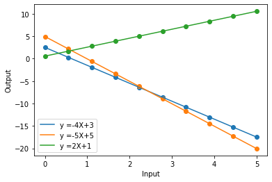

```python
#Do not modify this cell
vals = [(3, -4), (5, -5), (1, 2)]
for a, b in vals:
    L = simple_LR(a, b, 0, 5, 10)
    L.plot_equation()
```

# Task 2

## Part 1

You are required to implement a multivariate linear regression (`multivariate_LR`) class with 9 arguments.

\begin{equation} \hat y = \theta_0 + \sum_{i = 1}^{d} \theta_i X_i \end{equation}

**Description:**

- Before passing $X$ and $y$ to the class, make sure they are **2-D** numpy arrays.
- Initialize the arguments passed inside the constructor, normalize $X$ if `normalize = True`. Add an intercept column to $X$ if `intercept = True`. Also initialize a parameter $w$ which is a column vector that stores the weights. You should also randomly split $X$ and $y$ here based on the `train_size` argument. Also intialize the `loss_history` and `weight_history` parameters which store the loss and the weights respectively at each iteration.
- The `predict` function receives no arguments returns the prediction vector for the test $X$.
- The `mean_square_loss` function recevies 2 vectors $x$ and $y$ and returns the Euclidean distance between them.
- The `loss_derivative` function recevies 2 vectors $X$ and $y$ and returns the value of the **GRADIENT** with the current weights.
- The `gradient_descent` function recevies no arguments and performs gradient descent using the one of the 3 specified descent methods.
- The `plot_loss` function receives no arguments and plots the loss curve using `loss_history`.
- The `animate_gradient_descent` function receives no arguments and animates on a plot how the fitted line evolves on **1-D** using weights stored in `weight_history` . Use `time.sleep(1)` inside a for loop that iterates over `weight_history` plot the scatter of the original $X$ and $y$ variables as well as the fitted line at that iteration.
- The `adjusted_R_Squared` function receives no arguments and returns the adjusted $R^2$ value.

The code should be as vectorized as possible.

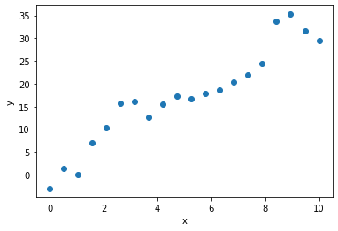

```python
#Do not modify this cell
X = np.linspace(0, 10, 20)
Y = 3 + 3 * X + np.random.normal(loc = 0, scale = 4, size = len(X))
X = X.reshape((len(X), 1))
Y = Y.reshape((len(X), 1))
graph = plt.figure()
graph = plt.scatter(X, Y)
graph = plt.xlabel('x')
graph = plt.ylabel('y')
```

```python
import matplotlib
from IPython.display import clear_output
class multivariate_LR():
    def __init__(self, X, Y, train_size, epochs, learning_rate, intercept, normalize, method, batch_size = 10):
      if( len(X.shape) < 2):
       X=np.reshape(X,(-1,2))

      if( len(Y.shape) < 2):
       Y=np.reshape(Y,(-1,2))

      self.X = X
      self.Y = Y
      self.train_size = train_size
      self.epochs = epochs
      self.learning_rate = learning_rate
      self.intercept = intercept
      self.normalize = normalize
      self.method = method
      self.batch_size = batch_size

      if normalize == True:
        self.X = np.linalg.norm(self.X)
      if intercept == True:
        np.append(self.X, np.zeros(len(self.X),1))

      self.X_train, X_test, self.y_train, y_test = train_test_split(self.X, self.Y, train_size=train_size, random_state=42, shuffle=True)

      if self.method == 'minibatch':
        self.X_train = self.X_train[:batch_size, :]
        self.y_train = self.X_train[:batch_size, :]
      #self.w = np.dot((np.dot( 1/( np.dot( X.transpose(), X ) ), X.transpose() )) , Y)
      #self.w = np.array([1] * len(self.X))
      #self.w = self.w.reshape(len(self.w),1)
      self.w = np.zeros(self.X_train.shape[1])

      self.cost_list = [0] * self.epochs
      self.loss_history = [0] * self.epochs
      self.weight_history = [0] * self.epochs
      self.predict_history = [0] * self.epochs

    def predict(self):
      return self.X_train.dot(self.w)
      pass

    def mean_square_loss(self, x, y):
      return  np.linalg.norm(x - y)
      pass

    def loss_derivative(self, x, y):
      loss = np.sum((((x.dot(self.w)) - y) ** 2) / (2*len(y)))
      return loss

    def gradient_descent(self):

      for i in range(self.epochs):
        if self.method == 'batch':
          loss = self.predict() - self.y_train
          weight_gradient = self.X_train.T.dot(loss) / len(self.y_train)
          #weight_gradient = (-1/len(self.y_train)) * sum(self.X_train * (loss))  #doing gradient descent
          self.w = np.subtract(self.w, (weight_gradient*self.learning_rate))

          cost = self.loss_derivative(self.X_train, self.y_train)
          self.cost_list[i] = cost

          self.loss_history[i] = loss
          self.weight_history[i] = self.w
          self.predict_history[i] = self.predict()

        #Write your code here
        elif self.method == 'sgd':
           #Write your code here
          pass
        elif self.method == 'minibatch':
          #Write your code here
          loss = self.predict() - self.y_train
          weight_gradient = self.X_train.T.dot(loss) / len(self.y_train)
          #weight_gradient = (-1/len(self.y_train)) * sum(self.X_train * (loss))  #doing gradient descent
          self.w = np.subtract(self.w, (weight_gradient*self.learning_rate))

          cost = self.loss_derivative(self.X_train, self.y_train)
          self.cost_list[i] = cost

          self.loss_history[i] = loss
          self.weight_history[i] = self.w
          self.predict_history[i] = self.predict()

    def plot_loss(self):
      plt.plot(self.cost_list)
      #self.plot_loss()
      pass

    def animate_gradient_descent(self):
      for i in range(self.epochs):
        time.sleep(1) #for plotting
        clear_output(wait=True) #for plotting
        plt.scatter(self.X, self.Y)
        plt.plot(self.X_train, self.predict_history[i] )
        plt.show()# function to show the plot
      pass

    def adjusted_R_squared(self):
      a = np.sum((self.predict() - self.Y) ** 2)
      b = np.sum((self.Y-self.Y.mean()) ** 2)
      R_squared = 1 - (a / b)
      return R_squared
      pass
```

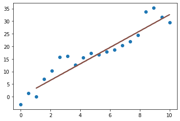

```python
#Do not modify this cell as this is for testing
multivariatelr = multivariate_LR(X, Y, 0.8, 20, 0.005, False, False, 'batch')
print(multivariatelr)
multivariatelr.gradient_descent()
multivariatelr.animate_gradient_descent()
```

## Part 2

Read the Bykea delivery dataset and split it into a feature matrix and an output vector that contains **delivery charge**.

```python
from google.colab import drive, output
drive.mount('/content/drive')
```

```python
#Write your code here
pdDf = pd.read_csv('/content/drive/MyDrive/delivery.csv')
pdDf.head()
```

|  | delivery_charge | pickup_longitude | pickup_latitude | dropoff_longitude | dropoff_latitude | delivery_items | hour_of_day | day_of_week |
| --- | --- | --- | --- | --- | --- | --- | --- | --- |
| 0 | 2750.0 | -73.990298 | 40.756037 | -73.969580 | 40.757542 | 1 | 11 | 1 |
| 1 | 1017.5 | -73.986566 | 40.744533 | -73.986101 | 40.751855 | 1 | 12 | 4 |
| 2 | 1925.0 | -73.981395 | 40.759807 | -73.969347 | 40.758840 | 1 | 11 | 1 |
| 3 | 6875.0 | -73.980735 | 40.738172 | -73.897968 | 40.754267 | 1 | 23 | 7 |
| 4 | 1787.5 | -73.974972 | 40.760130 | -73.989795 | 40.757066 | 1 | 19 | 6 |

Use the already imported `geodesic` function to calcuate distance between the pickup and dropoff points. Make a distance column in the feature matrix and drop the latitude and longitude columns. `geodesic` calculates distances as follows.

```python
pdDf["distance"] = 0.0

for x in range(len(pdDf)):
  pdDf.at[x, 'distance'] = (geodesic((pdDf.at[x, 'pickup_latitude'],pdDf.at[x, 'pickup_longitude']),(pdDf.at[x, 'dropoff_latitude'],pdDf.at[x, 'dropoff_longitude'] )).km)

pdDf.drop(columns=['pickup_longitude', 'pickup_latitude','dropoff_longitude', 'dropoff_latitude'], inplace=True)
YY = pdDf.iloc[:,:1].to_numpy()
XX=pdDf.iloc[:, -1:].to_numpy()
pdDf.head()
```

|  | delivery_charge | delivery_items | hour_of_day | day_of_week | distance |
| --- | --- | --- | --- | --- | --- |
| 0 | 2750.0 | 1 | 11 | 1 | 1.757469 |
| 1 | 1017.5 | 1 | 12 | 4 | 0.814049 |
| 2 | 1925.0 | 1 | 11 | 1 | 1.022991 |
| 3 | 6875.0 | 1 | 23 | 7 | 7.215141 |
| 4 | 1787.5 | 1 | 19 | 6 | 1.297098 |

```
array([[-7.60904039e+50, -7.60904039e+50, -7.60904039e+50, ...,
        -7.60904039e+50, -7.60904039e+50, -7.60904039e+50],
       [-9.38731517e+50, -9.38731517e+50, -9.38731517e+50, ...,
        -9.38731517e+50, -9.38731517e+50, -9.38731517e+50],
       [-1.17123599e+51, -1.17123599e+51, -1.17123599e+51, ...,
        -1.17123599e+51, -1.17123599e+51, -1.17123599e+51],
       ...,
       [-3.33007726e+51, -3.33007726e+51, -3.33007726e+51, ...,
        -3.33007726e+51, -3.33007726e+51, -3.33007726e+51],
       [-4.98711677e+50, -4.98711677e+50, -4.98711677e+50, ...,
        -4.98711677e+50, -4.98711677e+50, -4.98711677e+50],
       [-1.60431047e+51, -1.60431047e+51, -1.60431047e+51, ...,
        -1.60431047e+51, -1.60431047e+51, -1.60431047e+51]])
```

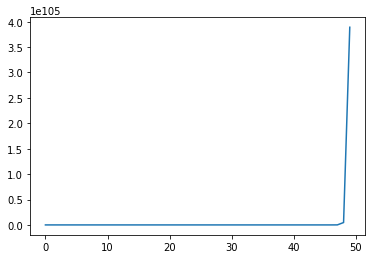

```python
#Write your code here
multivariatelr = multivariate_LR(XX, YY, 0.8, 50, 0.5, False, False, 'batch')
multivariatelr.gradient_descent()
multivariatelr.plot_loss()
#multivariatelr.adjusted_R_squared()
multivariatelr.predict()
```